# R Notebook

# Reading the Data into R

**Do the data have a header containing the variable names?** Yes there are variable names associated with the data.

**Are the values for an observation separated by a comma, blank, or tab?** They appear to be separated by a tab.

```r
github <- 'https://github.com/ucb-stat133/stat133-fall-2018/'
repo <- 'raw/master/data/saratoga.txt'
house <- read.table(paste0(github,repo), sep = "\t")
```

# Examine Price

```r
data <- tail(house, -1)
#data
summary(house)
```

```
##        V1             V2                V3             V4
##  120000 :  21   0.46   :  85   0         :1713   19     :  93
##  150000 :  21   0.15   :  74   1         :  15   16     :  88
##  225000 :  21   0.16   :  72   Waterfront:   1   18     :  88
##  155000 :  19   1      :  64                     0      :  83
##  195000 :  18   0.17   :  41                     1      :  75
##  145000 :  17   0.34   :  37                     15     :  71
##  (Other):1612   (Other):1356                     (Other):1231
##        V5                   V6                 V7               V8
##  27000  :  57   0            :1647   0          :1093   2        :1197
##  15100  :  51   1            :  81   1          : 635   3        : 315
##  15700  :  46   New.Construct:   1   Central.Air:   1   4        : 216
##  108900 :  27                                           Fuel.Type:   1
##  15000  :  20
##  25000  :  20
```

[output cut: 17 more lines]

```r
price <-as.numeric( data$V1)
max(price)
```

```
## [1] 751
```

```r
price_log <- log(price)

max(price_log)
```

```
## [1] 6.621406
```

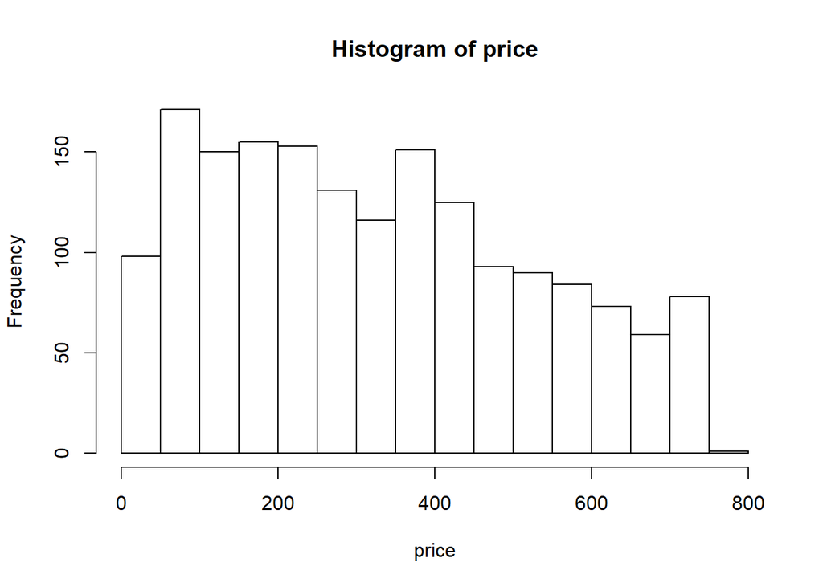

```r
hist(price)
```

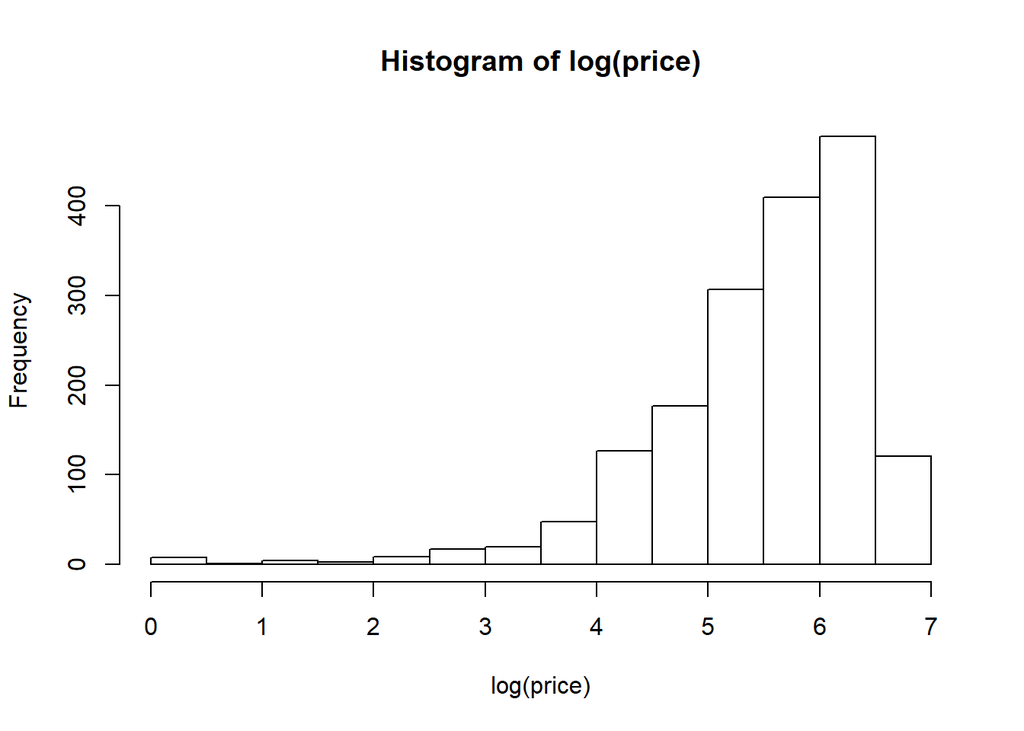

```r
hist(log(price))
```

```r
cheap <- (price_log < 10.5)
length(cheap)
```

```
## [1] 1728
```

```r
price[cheap]
```

```
##    [1]  87 239  27 161 729  55 154 210 737  62 554  55 727 749  74 736 161
##   [18] 426 687 732  35  13 138 144 739 415  95 126 661 111  82 257 379 374
##   [35] 235 209 328 209 503 408 165 284 144 389 479 410  65 103 499  25  94
##   [52] 693 117  68 734  95 737 738  73 221 168 742 721 111 211 306 106 370
##   [69] 242 325 254 746 435 177 742 332  42  38 346 126  40 107  11 209 229
##   [86]  89 253  42   1  50 144 258  20  73 132 689   3 120  39 712  29 734
##  [103]  25  41 130 370 103 354 420  35  37 749  57 699 370 274 169 411 278
##  [120]  99 709 656 403 737 168 219 144 173 108 724   5 221 716 384 747  54
##  [137] 130  68  95 166  95 118 438 725 237 188  19  42  42  95 295 106 320
##  [154]  55 319 471 106 736 110 217  98 460 219 612 616 125 582  89  42 333
##  [171] 376 190 571 110 480 370 123 598 411  55  98 378 184 382  45 221 445
##  [188] 130 315 449 200 316 210 222  86  43 144  55  68 144 597  91 740  11
##  [205] 136 242 153 749  38 215 235 722  51 225  24 744   7  93 144 192  55
##  [222] 227 515  64 114  15   2  26  16  28 216 197  14 670  55  24  48 696
##  [239]  52  46   1 211 260 111  66  21  24 236 339  77 324 110 583  25  43
```

[output cut: 87 more lines]

**How many houses are what we call cheap?** It seems like all of the houses are cheap, I can’t find any that are not cheap

# Explore Living Area

```r
house
```

| V1 | V2 | V3 | V4 | V5 | V6 | V7 | V8 | V9 | V10 | V11 | V12 | V13 | V14 | V15 | V16 |
| --- | --- | --- | --- | --- | --- | --- | --- | --- | --- | --- | --- | --- | --- | --- | --- |
| Price | Lot.Size | Waterfront | Age | Land.Value | New.Construct | Central.Air | Fuel.Type | Heat.Type | Sewer.Type | Living.Area | Pct.College | Bedrooms | Fireplaces | Bathrooms | Rooms |
| 132500 | 0.09 | 0 | 42 | 50000 | 0 | 0 | 3 | 4 | 2 | 906 | 35 | 2 | 1 | 1 | 5 |
| 181115 | 0.92 | 0 | 0 | 22300 | 0 | 0 | 2 | 3 | 2 | 1953 | 51 | 3 | 0 | 2.5 | 6 |
| 109000 | 0.19 | 0 | 133 | 7300 | 0 | 0 | 2 | 3 | 3 | 1944 | 51 | 4 | 1 | 1 | 8 |
| 155000 | 0.41 | 0 | 13 | 18700 | 0 | 0 | 2 | 2 | 2 | 1944 | 51 | 3 | 1 | 1.5 | 5 |
| 86060 | 0.11 | 0 | 0 | 15000 | 1 | 1 | 2 | 2 | 3 | 840 | 51 | 2 | 0 | 1 | 3 |
| 120000 | 0.68 | 0 | 31 | 14000 | 0 | 0 | 2 | 2 | 2 | 1152 | 22 | 4 | 1 | 1 | 8 |
| 153000 | 0.4 | 0 | 33 | 23300 | 0 | 0 | 4 | 3 | 2 | 2752 | 51 | 4 | 1 | 1.5 | 8 |
| 170000 | 1.21 | 0 | 23 | 14600 | 0 | 0 | 4 | 2 | 2 | 1662 | 35 | 4 | 1 | 1.5 | 9 |
| 90000 | 0.83 | 0 | 36 | 22200 | 0 | 0 | 3 | 4 | 2 | 1632 | 51 | 3 | 0 | 1.5 | 8 |

[output cut: 1719 more lines]

```r
data
```

|  | V1 | V2 | V3 | V4 | V5 | V6 | V7 | V8 | V9 | V10 | V11 | V12 | V13 | V14 | V15 | V16 |
| --- | --- | --- | --- | --- | --- | --- | --- | --- | --- | --- | --- | --- | --- | --- | --- | --- |
| 2 | 132500 | 0.09 | 0 | 42 | 50000 | 0 | 0 | 3 | 4 | 2 | 906 | 35 | 2 | 1 | 1 | 5 |
| 3 | 181115 | 0.92 | 0 | 0 | 22300 | 0 | 0 | 2 | 3 | 2 | 1953 | 51 | 3 | 0 | 2.5 | 6 |
| 4 | 109000 | 0.19 | 0 | 133 | 7300 | 0 | 0 | 2 | 3 | 3 | 1944 | 51 | 4 | 1 | 1 | 8 |
| 5 | 155000 | 0.41 | 0 | 13 | 18700 | 0 | 0 | 2 | 2 | 2 | 1944 | 51 | 3 | 1 | 1.5 | 5 |
| 6 | 86060 | 0.11 | 0 | 0 | 15000 | 1 | 1 | 2 | 2 | 3 | 840 | 51 | 2 | 0 | 1 | 3 |
| 7 | 120000 | 0.68 | 0 | 31 | 14000 | 0 | 0 | 2 | 2 | 2 | 1152 | 22 | 4 | 1 | 1 | 8 |
| 8 | 153000 | 0.4 | 0 | 33 | 23300 | 0 | 0 | 4 | 3 | 2 | 2752 | 51 | 4 | 1 | 1.5 | 8 |
| 9 | 170000 | 1.21 | 0 | 23 | 14600 | 0 | 0 | 4 | 2 | 2 | 1662 | 35 | 4 | 1 | 1.5 | 9 |
| 10 | 90000 | 0.83 | 0 | 36 | 22200 | 0 | 0 | 3 | 4 | 2 | 1632 | 51 | 3 | 0 | 1.5 | 8 |
| 11 | 122900 | 1.94 | 0 | 4 | 21200 | 0 | 0 | 2 | 2 | 1 | 1416 | 44 | 3 | 0 | 1.5 | 6 |

[output cut: 1718 more lines]

```r
living <- as.numeric(data$V11)
living
```

```
##    [1] 856 437 434 434 847  49 732 287 275 166 754 272 835 149 113 866 113
##   [18] 744 862  27  20 259 243 490 259 553 285  54 642 225  75 392 551 398
##   [35] 467 293 481 402 465 622 153 438 230 447 650 719 842 205 381  16 352
##   [52] 197 171 161 197 134 197 197 256 347 136 197 199 243   3 601  23 634
##   [69] 117 287 456 197 768 224 215 541 197 181 610 178 197 400 197 357 152
##   [86] 298 838 233   1 298 285 587 318 137 298 122  20 858  82 148 866 837
##  [103] 273  46 376 354 387 540 860 104  82 162  52  65 546 401 143 414 226
##  [120] 854   3 858 636 855 498 510 134  32 178 847  54 289 776 686 847 313
##  [137] 184  77 165 263 774 412 671  14 372 543 619 143 197 136 407 133 461
##  [154]  59 449 566 262  64 260 337  27 628 431 780 828 299 757 155  21 603
##  [171] 546 211 746  93 602 518 133 767 509  46 876 194  88 420 178 256 704
##  [188] 450 268 424 685 383 140 289  29  70  17  46  44  82 774 207 858 207
##  [205] 234 692 866 858 203 258 589 858 151 234 853 858 858 150 127 174 203
##  [222] 234 866 203 389  86 858 858 858  61 279 207 834 135  61 858 858 876
##  [239]  61 151 858 227 234   3 151 857 562 372 675 845 641 124 759  12 858
```

[output cut: 87 more lines]

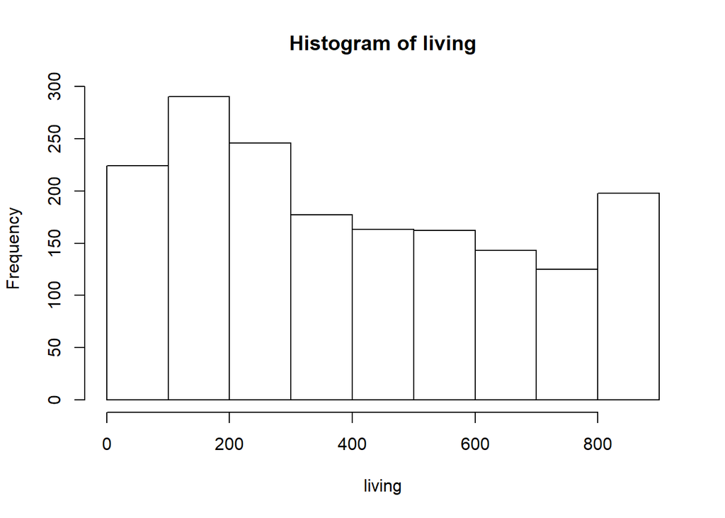

```r
hist(living)
```

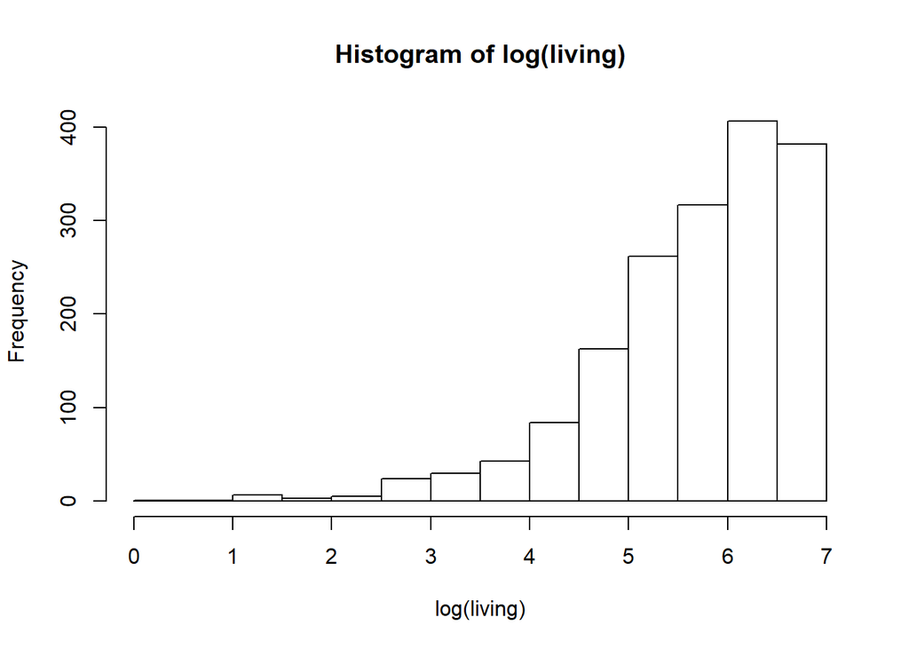

```r
hist(log(living))
```

**What value does 6.8 correspond to with the initial terms of measurement?** It corresponds to e^6.8 which equals a square footage of 898.

# Tranforming Variables into Factors

```r
house
```

| V1 | V2 | V3 | V4 | V5 | V6 | V7 | V8 | V9 | V10 | V11 | V12 | V13 | V14 | V15 | V16 |
| --- | --- | --- | --- | --- | --- | --- | --- | --- | --- | --- | --- | --- | --- | --- | --- |
| Price | Lot.Size | Waterfront | Age | Land.Value | New.Construct | Central.Air | Fuel.Type | Heat.Type | Sewer.Type | Living.Area | Pct.College | Bedrooms | Fireplaces | Bathrooms | Rooms |
| 132500 | 0.09 | 0 | 42 | 50000 | 0 | 0 | 3 | 4 | 2 | 906 | 35 | 2 | 1 | 1 | 5 |
| 181115 | 0.92 | 0 | 0 | 22300 | 0 | 0 | 2 | 3 | 2 | 1953 | 51 | 3 | 0 | 2.5 | 6 |
| 109000 | 0.19 | 0 | 133 | 7300 | 0 | 0 | 2 | 3 | 3 | 1944 | 51 | 4 | 1 | 1 | 8 |
| 155000 | 0.41 | 0 | 13 | 18700 | 0 | 0 | 2 | 2 | 2 | 1944 | 51 | 3 | 1 | 1.5 | 5 |
| 86060 | 0.11 | 0 | 0 | 15000 | 1 | 1 | 2 | 2 | 3 | 840 | 51 | 2 | 0 | 1 | 3 |
| 120000 | 0.68 | 0 | 31 | 14000 | 0 | 0 | 2 | 2 | 2 | 1152 | 22 | 4 | 1 | 1 | 8 |
| 153000 | 0.4 | 0 | 33 | 23300 | 0 | 0 | 4 | 3 | 2 | 2752 | 51 | 4 | 1 | 1.5 | 8 |
| 170000 | 1.21 | 0 | 23 | 14600 | 0 | 0 | 4 | 2 | 2 | 1662 | 35 | 4 | 1 | 1.5 | 9 |
| 90000 | 0.83 | 0 | 36 | 22200 | 0 | 0 | 3 | 4 | 2 | 1632 | 51 | 3 | 0 | 1.5 | 8 |

[output cut: 1719 more lines]

```r
BR <- as.numeric(data$V13)
BR[ BR > 5 ] <- 5
BR[ BR < 2] <- 2
BR <- factor(BR, labels = c("2-BR", "3 BR", "4 BR", "5+ BR") )
BR
```

```
##    [1] 2-BR  3 BR  4 BR  3 BR  2-BR  4 BR  4 BR  4 BR  3 BR  3 BR  5+ BR
##   [12] 3 BR  2-BR  3 BR  3 BR  3 BR  3 BR  4 BR  2-BR  3 BR  3 BR  3 BR
##   [23] 3 BR  3 BR  3 BR  4 BR  3 BR  4 BR  4 BR  3 BR  2-BR  3 BR  3 BR
##   [34] 3 BR  4 BR  4 BR  4 BR  4 BR  4 BR  4 BR  3 BR  4 BR  3 BR  3 BR
##   [45] 4 BR  4 BR  2-BR  3 BR  4 BR  2-BR  3 BR  2-BR  3 BR  3 BR  3 BR
##   [56] 3 BR  2-BR  3 BR  3 BR  3 BR  2-BR  3 BR  3 BR  4 BR  2-BR  4 BR
##   [67] 3 BR  4 BR  3 BR  3 BR  4 BR  3 BR  4 BR  3 BR  4 BR  4 BR  3 BR
##   [78] 3 BR  4 BR  3 BR  2-BR  3 BR  3 BR  3 BR  3 BR  2-BR  4 BR  3 BR
##   [89] 3 BR  4 BR  3 BR  3 BR  3 BR  3 BR  3 BR  3 BR  3 BR  3 BR  2-BR
##  [100] 3 BR  3 BR  3 BR  2-BR  3 BR  3 BR  3 BR  3 BR  4 BR  2-BR  3 BR
##  [111] 3 BR  3 BR  3 BR  3 BR  4 BR  3 BR  3 BR  3 BR  3 BR  3 BR  3 BR
##  [122] 2-BR  3 BR  4 BR  3 BR  4 BR  2-BR  3 BR  3 BR  2-BR  2-BR  4 BR
##  [133] 4 BR  4 BR  2-BR  5+ BR 3 BR  3 BR  3 BR  3 BR  4 BR  3 BR  4 BR
##  [144] 2-BR  3 BR  3 BR  3 BR  2-BR  2-BR  2-BR  4 BR  2-BR  3 BR  2-BR
##  [155] 3 BR  3 BR  2-BR  3 BR  2-BR  3 BR  3 BR  4 BR  3 BR  4 BR  5+ BR
```

[output cut: 144 more lines]

```r
summary(BR)
```

```
##  2-BR  3 BR  4 BR 5+ BR
##   355   822   487    64
```

```r
summary(house$v13)
```

```
## Length  Class   Mode
##      0   NULL   NULL
```

**How does a summary of BR look different than a summary of Bedrooms?** The summary of BR looks different than Bedrooms because with the summary of bedrooms within house it just returns length zero and class and mode of NULL. But with the summary of BR it returns the number of houses that fall into the different categories of bedrooms.

# Plotting Price against Living Area

[figure not shown]

```r
my_colors <-  c("aquamarine3", "darkgoldenrod2", "coral2", "mediumorchid3")
br_colors <- my_colors[BR]

plot(V1 ~ V11, data = data, log = 'xy', main = '', xlab = "Living Area (log sq ft)", ylab = "Price (log$)", col = br_colors, pch = 19, cex = 0.4)
legend("bottomright", fill = my_colors, legend = levels(BR), title = "# Bedrooms", cex = 0.75)
```

# Number of Fireplaces

```r
house
```

| V1 | V2 | V3 | V4 | V5 | V6 | V7 | V8 | V9 | V10 | V11 | V12 | V13 | V14 | V15 | V16 |
| --- | --- | --- | --- | --- | --- | --- | --- | --- | --- | --- | --- | --- | --- | --- | --- |
| Price | Lot.Size | Waterfront | Age | Land.Value | New.Construct | Central.Air | Fuel.Type | Heat.Type | Sewer.Type | Living.Area | Pct.College | Bedrooms | Fireplaces | Bathrooms | Rooms |
| 132500 | 0.09 | 0 | 42 | 50000 | 0 | 0 | 3 | 4 | 2 | 906 | 35 | 2 | 1 | 1 | 5 |
| 181115 | 0.92 | 0 | 0 | 22300 | 0 | 0 | 2 | 3 | 2 | 1953 | 51 | 3 | 0 | 2.5 | 6 |
| 109000 | 0.19 | 0 | 133 | 7300 | 0 | 0 | 2 | 3 | 3 | 1944 | 51 | 4 | 1 | 1 | 8 |
| 155000 | 0.41 | 0 | 13 | 18700 | 0 | 0 | 2 | 2 | 2 | 1944 | 51 | 3 | 1 | 1.5 | 5 |
| 86060 | 0.11 | 0 | 0 | 15000 | 1 | 1 | 2 | 2 | 3 | 840 | 51 | 2 | 0 | 1 | 3 |
| 120000 | 0.68 | 0 | 31 | 14000 | 0 | 0 | 2 | 2 | 2 | 1152 | 22 | 4 | 1 | 1 | 8 |
| 153000 | 0.4 | 0 | 33 | 23300 | 0 | 0 | 4 | 3 | 2 | 2752 | 51 | 4 | 1 | 1.5 | 8 |
| 170000 | 1.21 | 0 | 23 | 14600 | 0 | 0 | 4 | 2 | 2 | 1662 | 35 | 4 | 1 | 1.5 | 9 |
| 90000 | 0.83 | 0 | 36 | 22200 | 0 | 0 | 3 | 4 | 2 | 1632 | 51 | 3 | 0 | 1.5 | 8 |

[output cut: 1719 more lines]

```r
FP <- factor(data$V14)


FP <- as.numeric(as.character(FP))

FP[FP >= 1] <- "At least 1"
FP[FP == 0] <- "None"
FP
```

```
##    [1] "At least 1" "None"       "At least 1" "At least 1" "None"
##    [6] "At least 1" "At least 1" "At least 1" "None"       "None"
##   [11] "None"       "None"       "None"       "None"       "None"
##   [16] "None"       "None"       "At least 1" "None"       "None"
##   [21] "None"       "None"       "None"       "None"       "None"
##   [26] "None"       "None"       "None"       "At least 1" "At least 1"
##   [31] "At least 1" "At least 1" "At least 1" "None"       "At least 1"
##   [36] "At least 1" "At least 1" "At least 1" "At least 1" "At least 1"
##   [41] "At least 1" "None"       "At least 1" "None"       "At least 1"
##   [46] "At least 1" "None"       "None"       "None"       "At least 1"
##   [51] "None"       "At least 1" "At least 1" "None"       "At least 1"
##   [56] "None"       "At least 1" "At least 1" "None"       "At least 1"
##   [61] "At least 1" "At least 1" "None"       "At least 1" "None"
##   [66] "None"       "At least 1" "At least 1" "At least 1" "None"
##   [71] "None"       "At least 1" "At least 1" "None"       "None"
```

[output cut: 331 more lines]

```r
price <- as.numeric(as.character(house$V1))
sqft <- as.numeric(as.character(house$V11))
pps <- price/sqft
pps
```

```
##    [1]         NA 146.247241  92.736815  56.069959  79.732510 102.452381
##    [7] 104.166667  55.595930 102.286402  55.147059  86.793785 112.301313
##   [13]  73.891626 121.960227  70.137383  97.692308  96.047009 119.230769
##   [19]  90.110085  64.935065  80.128205 106.060606  65.562500  94.311548
##   [25]  72.115385  56.500000 111.870504  81.521739 123.931624 185.696871
##   [31]  90.673575 106.557377 100.645856 103.199639 121.002132  88.795656
##   [37] 101.675643 101.893204  90.180467 144.906034 102.715121 112.949640
##   [43]  99.795292  96.525097 118.876518 112.767245  90.825350 155.583438
##   [49]  92.000000 157.780196 103.646833  75.701459  43.581081  99.579243
##   [55]  89.031339  59.459459 100.446429  60.810811  60.878378  79.511278
##   [61]  98.981900 117.210682  62.162162  55.832771  88.832487 169.642857
##   [67]  86.037736 130.639098  92.668863 138.931298 125.611913  93.000000
##   [73]  62.837838  86.691142 104.409857  60.248854  96.128474  77.702703
##   [79]  77.823691  91.652542 100.694444  77.027027  74.002129  70.270270
##   [85]  94.810268 128.354978  79.355609 240.885417  73.717949 100.000000
```

[output cut: 274 more lines]

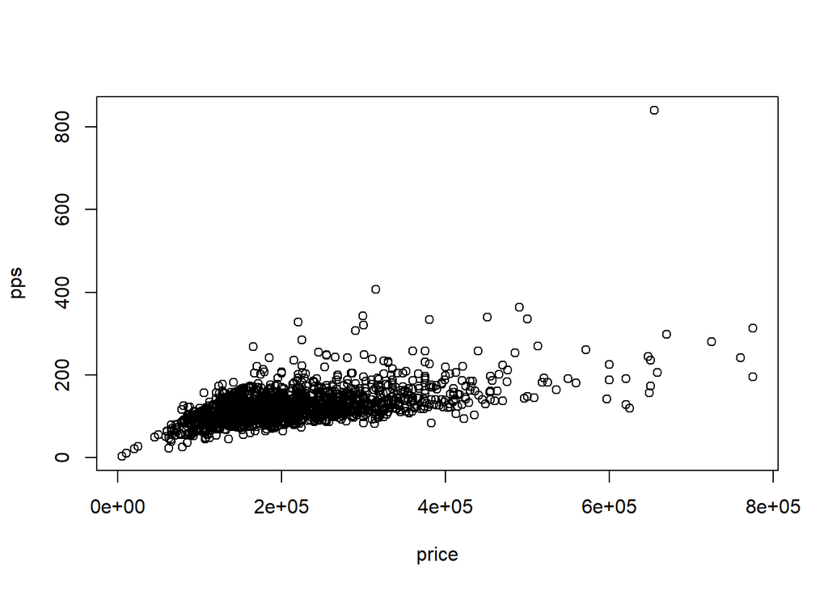

```r
plot(price, pps)
```

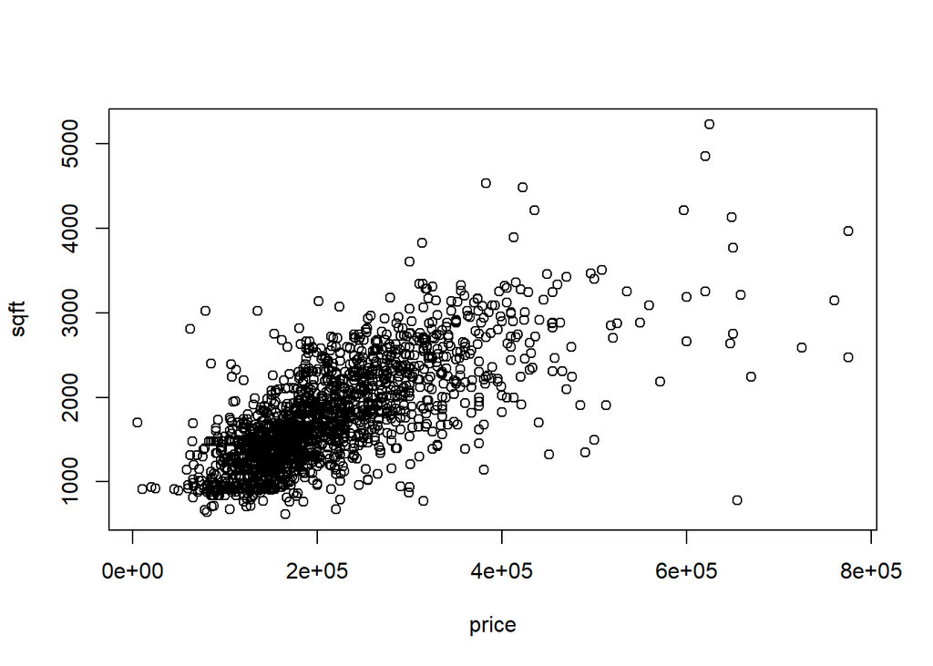

```r
plot(price, sqft)
```

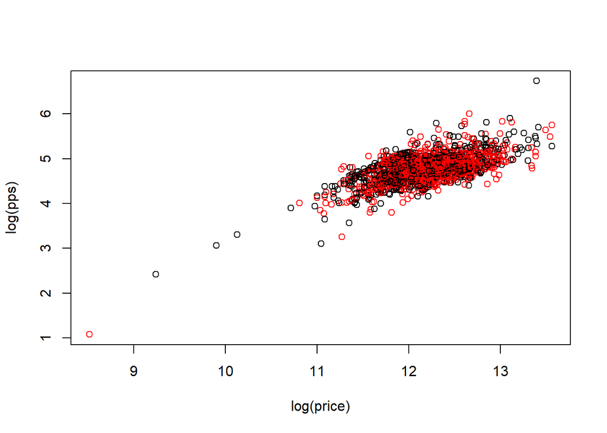

```r
plot(log(price), log(pps), col = ifelse(FP == "None", 'black', 'red'))
```

**Are houses with fireplaces generally more expensive than houses without?** No, I would say that houses with fireplaces are typically the same price as houses without fireplaces.